# Stats 20, Winter 2017

# Yang Pochao 204631541

Part I: Introduction

We are provided with three datasets. The first one is edmunds, which describes a lead being submitted to Edmunds.com about a car that a consumer expressed interest in. The second one is IRS, which is aggregated information from IRS tax returns based on the returns coming from residents of different zip codes from the year 2013. The last one is towers, which is information about individual cell towers located in Los Angeles.

We first clean the datasets, and then pick some useful and interesting variables to examine by subsetting. Therefore, we then generate some t-test and linear models to test some hypothesises we make and get a more explicit understanding of the datasets graphically and statistically.

For people who want to buy a car, when they are using edmunds website, they can get information back from the database, which is modified and analyzed by us. If people are interested in how cell towers are distributed in each state, or each small region represented by a zip code, our dataset may be really helpful. Irs dataset is the most important one according to my understanding, since tax report for individuals and families can provide a lot information to the government when they are making policies.

Part II: Data

1. Dimensions of towers and edmunds and irs are [1] 9248 22 [1] 2445924 24 [1] 288 111
2. Columns of towers and edmunds and irs after cleaning are [1] 5 [1] 11 [1] 8

```r
#Load the data

###Load or read
towers.all <- read.csv("la-cell-towers.csv", header = TRUE)
edmunds.all <- read_dta("edmunds.dta")
irs.all <- read_excel("irs-la-zip.xls")

###Observationos of each dataset
#Edmunds: a lead being submitted to Edmunds.com about a car that a consumer expressed interest in.
#Towers: individual cell towers located in Los Angeles
#Irs: IRS tax returns from each resident from 2013.

###Dimensions of each dataset
#dim(towers.all)
#dim(edmunds.all)
#dim(irs.all)

###Drop unneeded variables for each dataset
towers <- towers.all[ , c("OBJECTID", "city", "ZIP", "longitude", "latitude")]
edmunds <- edmunds.all[ , c("lead_id", "lead_date", "visitor_key", "make", "model", "model_year", "msrp", "dealer_state", "dealer_zip")]
irs <- irs.all[ , c("ZIPCODE", "N1", "MARS1", "MARS2", "MARS4", "NUMDEP", "A00100")]

###Number of variables of each dataset after dropping
#ncol(towers)
#ncol(edmunds)
#ncol(irs)
```

```r
#Clean the data

###Edmunds data
#####Missing values
edmunds <- replace(edmunds, edmunds == c("", "NA", "INA"), NA)
#####Fix variable make
edmunds$make <- toupper(as.factor(edmunds$make))
#####Fix class of some variables
edmunds$model_year <- as.numeric(edmunds$model_year)
edmunds$msrp <- as.numeric(edmunds$msrp)
edmunds$dealer_zip <- as.numeric(edmunds$dealer_zip)
#####Create two variables
edmunds <- mutate(edmunds, lead_year = format(as.Date(edmunds$lead_date, "%Y-%m-%d"), "%Y"), lead_month = format(as.Date(edmunds$lead_date, "%Y-%m-%d"), "%Y-%m"))
###Irs data
#####Create one variable
irs$AGIperReturn <- irs$A00100/irs$N1

###Cell towers data
```

1. It gets a large increase in 2013-12. The trend is basically increasing, and later with small variations.
2. CA has the most leads.
3. Toyota is the most popular one.
4. No retailing price isn’t determined by the popularity of makes.
5. No, I don’t want to test any hypothesis.
6. 91042 is the zip code with most cell towers.

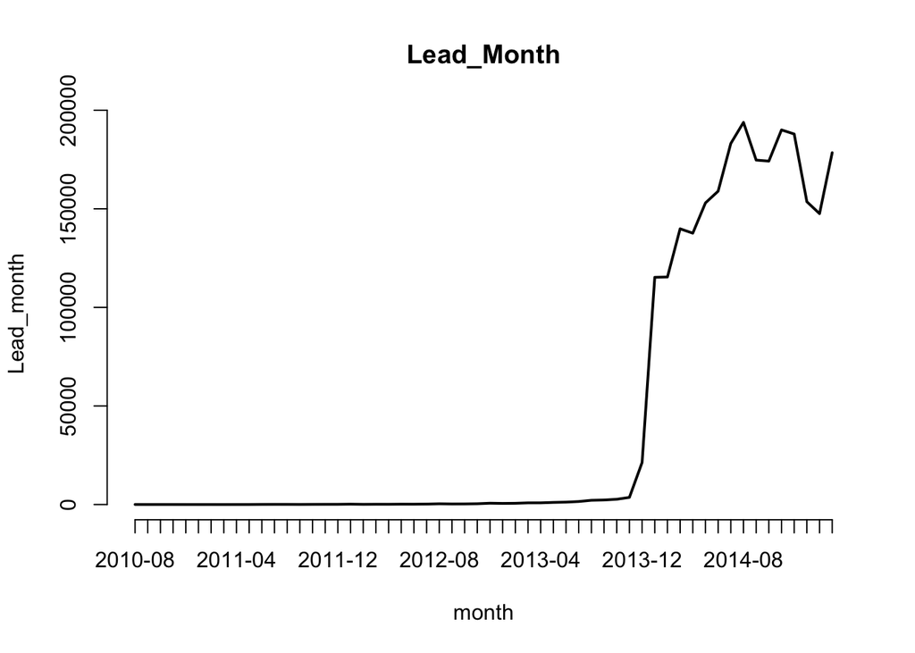

```r
#Data summarization

###Edmunds data
#####Generate a line graph
plot(table(edmunds$lead_month), "l", xlab = "month", ylab = "Lead_month", main = "Lead_Month")
```

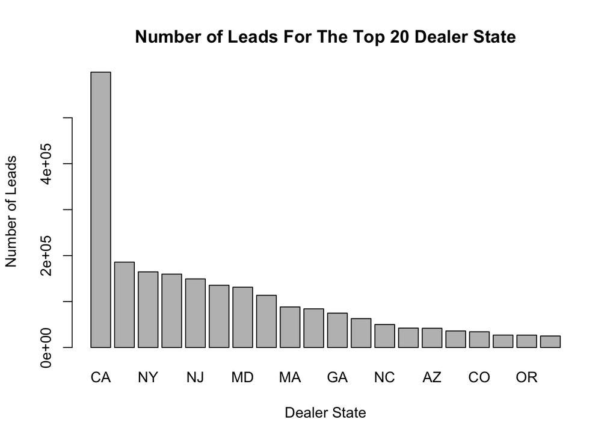

```r
#####Generate a barplot
top20 <- head(sort(table(edmunds$dealer_state), d = TRUE), 20)
barplot(top20, main = "Number of Leads For The Top 20 Dealer State", xlab = "Dealer State", ylab = "Number of Leads")
```

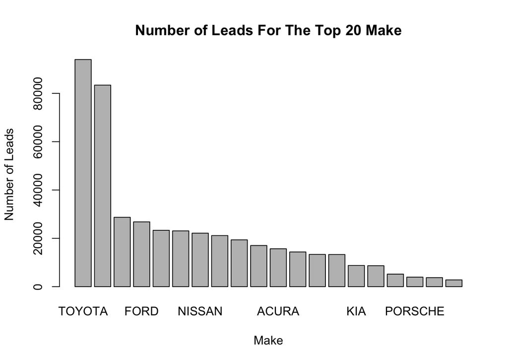

```r
#####Extract a subset
subedmunds <- subset(edmunds, lead_year == "2014" & dealer_state == "CA")
#####Generate a barplot
top20_make <- head(sort(table(subedmunds$make), decreasing = TRUE), 20)
barplot(top20_make, main = "Number of Leads For The Top 20 Make", xlab = "Make", ylab = "Number of Leads")
```

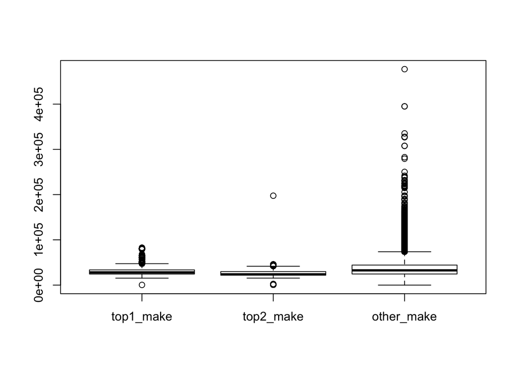

```r
#####Generate a boxplot
submsrp <- list(top1_make = subset(subedmunds$msrp, subedmunds$make == "TOYOTA"), top2_make = subset(subedmunds$msrp, subedmunds$make == "HONDA"), other_make = subset(subedmunds$msrp, subedmunds$make != "TOYOTA" & subedmunds$make != "HONDA"))
boxplot(submsrp)
```

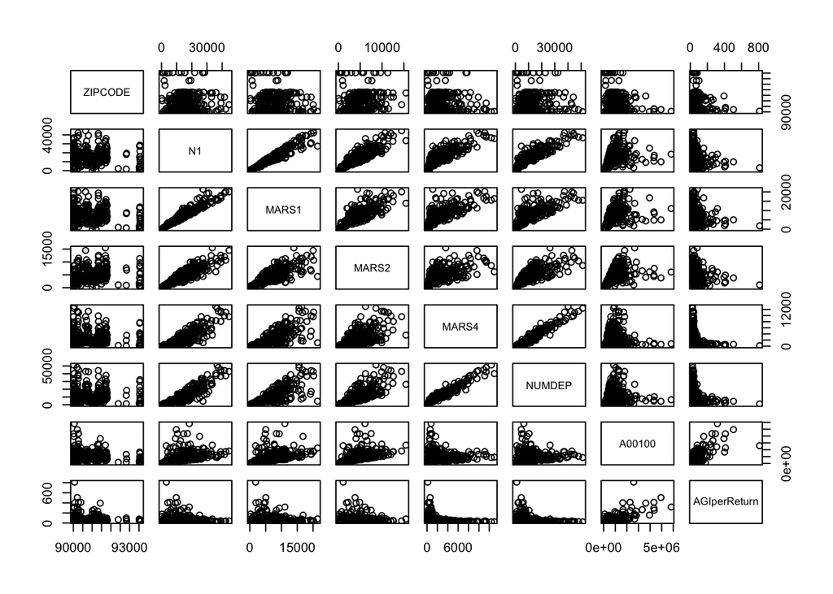

```r
#####Create a table
subdealer_zip <- group_by(subedmunds, dealer_zip)
aggrtable <- summarise(subdealer_zip, msrp.med = median(msrp, na.rm = TRUE), lead.count = length(which(dealer_zip == dealer_zip)))

###Irs data
#####Create a scatter plot
newirs <- irs[ ,c("N1","MARS1","MARS2","MARS4","NUMDEP","A00100")]
pairs(irs)
```

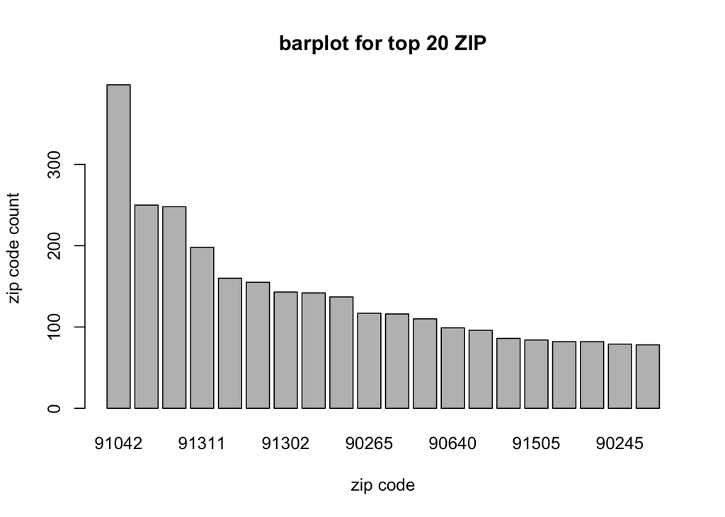

```r
###Cell towers data
#####Generate a barplot
barplot(head(sort(table(towers$ZIP), decreasing = T), 20), xlab = "zip code", ylab = "zip code count", main = "barplot for top 20 ZIP")
```

```r
citytowers <- subset(towers$city, towers$ZIP == "91042")
#####Create a table
subzip <- group_by(towers, ZIP)
aggrtable2 <- summarise(subzip, cel.count = length(which(ZIP == ZIP)), lon.med = median(longitude, na.rm = TRUE), lat.med = median(latitude, na.rm = TRUE))
```

1. Merges dataset has 13 elements.

```r
#Merge or join datasets

###Append the information
merge1 <- merge(irs, aggrtable, by.x = "ZIPCODE", by.y = "dealer_zip", all.x = TRUE)
merge2 <- merge(merge1, aggrtable2, by.x = "ZIPCODE", by.y = "ZIP", all.x = TRUE)

###Number of dimensions
#ncol(merge2)
```

Part III: Statistical Inference

```r
#T-test

###Perform test
t.test(submsrp$top1_make, submsrp$top2_make, "two.sided")
```

```
##
##  Welch Two Sample t-test
##
## data:  submsrp$top1_make and submsrp$top2_make
## t = 45.93, df = 33053, p-value < 2.2e-16
## alternative hypothesis: true difference in means is not equal to 0
## 95 percent confidence interval:
##  3472.027 3781.567
## sample estimates:
## mean of x mean of y
##  29642.73  26015.93
```

```r
t.test(submsrp$top1_make, submsrp$other_make, "two.sided")
```

```
##
##  Welch Two Sample t-test
##
## data:  submsrp$top1_make and submsrp$other_make
## t = -75.789, df = 65624, p-value < 2.2e-16
## alternative hypothesis: true difference in means is not equal to 0
## 95 percent confidence interval:
##  -7398.679 -7025.647
## sample estimates:
## mean of x mean of y
##  29642.73  36854.89
```

```r
t.test(submsrp$top2_make, submsrp$other_make, "two.sided")
```

```
##
##  Welch Two Sample t-test
##
## data:  submsrp$top2_make and submsrp$other_make
## t = -126.4, df = 79239, p-value < 2.2e-16
## alternative hypothesis: true difference in means is not equal to 0
## 95 percent confidence interval:
##  -11007.04 -10670.88
## sample estimates:
## mean of x mean of y
##  26015.93  36854.89
```

1. I think the variable the median suggested retail price of the lead and the adjusted gross income per number of returns in the dataset has a positive linear relationship.

```r
#Linear regression

###Linear relationship
#pairs(merge2)
fit <- lm(merge2$msrp.med ~ merge2$AGIperReturn)

###Fit a linear model
#coef(fit)
summary(fit)
```

```
##
## Call:
## lm(formula = merge2$msrp.med ~ merge2$AGIperReturn)
##
## Residuals:
##    Min     1Q Median     3Q    Max
## -19772  -5380  -3160   1934  32493
##
## Coefficients:
##                     Estimate Std. Error t value Pr(>|t|)
## (Intercept)         26801.63    1909.53   14.04  < 2e-16 ***
## merge2$AGIperReturn    93.68      17.61    5.32 1.33e-06 ***
## ---
## Signif. codes:  0 '***' 0.001 '**' 0.01 '*' 0.05 '.' 0.1 ' ' 1
##
## Residual standard error: 10130 on 66 degrees of freedom
##   (220 observations deleted due to missingness)
## Multiple R-squared:  0.3002, Adjusted R-squared:  0.2896
## F-statistic: 28.31 on 1 and 66 DF,  p-value: 1.328e-06
```

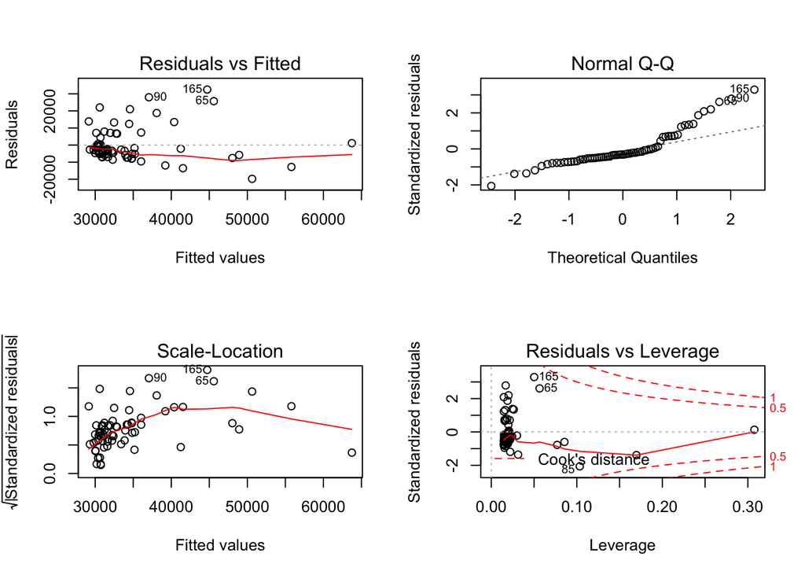

```r
par(mfrow = c(2, 2))
plot(fit, 1)
plot(fit, 2)
plot(fit, 3)
plot(fit, 5)
```

```r
#Custom functions

###Create a function
my.function <- function(zip) {
  if(anyNA(match(zip, merge2$ZIPCODE))) {
    stop("input includes non-recorded zip code")
  }
  result <- data.frame(zip = numeric(length = length(zip)), cel.count = numeric(length =
  length(zip)), N1 = numeric(length = length(zip)), lead.count = numeric(length = length(zip)))
  for(i in 1:length(zip)) {
    funczip <- subset(merge2, ZIPCODE == zip[i])
    result[i, 2:4] <- summarise(funczip, cel.count = cel.count, N1 = N1, lead.count = lead.count)
    result[i, 1] <- zip[i]
  }
  result
}
#my.function(zip = c("90001", "19428", "00033"))
#my.function(zip = c("90001", "19428", "00033", "1004"))
#my.function(zip = c("90001", "19428", "00033", NA))
```

1. For all the three t-tests performed before, since p-value all smaller than 0.01, which suggested statistically significant, all the three null hypothesises are rejected. The two variables being compared are not same with each other.
2. Since the coefficients are (Intercept) merge2$AGIperReturn 26801.63197 93.68374 therefore we know that if AGIperReturn increased by 1, then the median msrp will increase by 93.68374 correspondingly. If we want to improve our model, we have to eliminate outliers since they are very influencing.
3. Tests of my functinos all print out the error message I want to see since there’s invalid zip code in all of the three outputs. “Error in my.function(zip = c(”90001“,”19428“,”00033“, NA)) : input includes non-recorded zip code”

```r
#Results and conclusions

###The result of t-tests

###The result of linear model

###The result of my function
#my.function(zip = c("90001", "19428", "00033"))
#my.function(zip = c("90001", "19428", "00033", "1004"))
#my.function(zip = c("90001", "19428", "00033", NA))
```